# Punto V — Modelo de Índice Único

Taller de Matemáticas avanzadas para finanzas — Fundamentos Estadísticos para Finanzas Analíticas

Autor/a

Palacio Esteban, Duarte Sebastian

Fecha de publicación

17 de agosto de 2026

# 1 Configuración

El **Modelo de Índice Único** plantea una relación lineal entre el retorno de un activo y el del mercado:

$$R_{i,t} = \alpha_i + \beta_i\,R_{M,t} + \varepsilon_t,$$

donde $\alpha_i$ es el rendimiento anormal, $\beta_i$ el riesgo sistemático (sensibilidad al mercado) y $\varepsilon_t$ el riesgo específico de la empresa. Se seleccionan **tres acciones que cotizan en la misma bolsa** y el **índice** que representa ese mercado. Toda la selección se controla en el bloque siguiente (edítelo para analizar otras acciones u otro índice/tasa/pesos).

**Ver código**

```r
# =============================================================================
# EDITE AQUÍ. Use los símbolos tal como aparecen en Yahoo Finance.
# =============================================================================
INDICE     <- "^NYA"                 # índice de mercado (NYSE Composite)
ACCIONES   <- c("PG", "TSM", "JPM")  # 3 acciones de la MISMA bolsa que el índice
RF_ANUAL   <- 0.0469                 # tasa libre de riesgo anual efectiva
PESOS_PORT <- rep(1 / 3, 3)          # pesos del portafolio (pregunta 8): iguales,
                                     # cambiables (deben sumar 1 y respetar length(ACCIONES))
ANIOS      <- 4                      # años de historia diaria
DIAS       <- 252                    # días bursátiles para anualizar
# =============================================================================
```

**Ver código**

```r
fecha_final   <- Sys.Date()
fecha_inicial <- fecha_final %m-% years(ANIOS)

precios_acc <- descargar_precios_v(ACCIONES, fecha_inicial, fecha_final)
precio_idx  <- descargar_precio_v(INDICE, fecha_inicial, fecha_final)
todo <- na.omit(merge(precios_acc, precio_idx))
colnames(todo) <- c(ACCIONES, "Mercado")

ret <- retornos_log_v(todo)
Rm  <- as.numeric(ret[, "Mercado"])

regs  <- lapply(ACCIONES, function(a) regresion_indice_unico(as.numeric(ret[, a]), Rm, a))
names(regs) <- ACCIONES
betas <- sapply(regs, function(r) r$beta)

cat("Índice:", INDICE, "| Acciones:", paste(ACCIONES, collapse = ", "),
    "| Observaciones:", nrow(ret),
    "| Periodo:", as.character(min(zoo::index(ret))), "a",
    as.character(max(zoo::index(ret))), "\n")
```

```
Índice: ^NYA | Acciones: PG, TSM, JPM | Observaciones: 1002 | Periodo: 2022-08-18 a 2026-08-17
```

# 2 1) Estimación del modelo y parámetros

**Ver código**

```r
tab1 <- do.call(rbind, lapply(regs, function(r) data.frame(
  Activo = r$nombre,
  Alpha = r$alpha, EE_Alpha = r$se_alpha, t_Alpha = r$t_alpha,
  Beta = r$beta,  EE_Beta = r$se_beta,  t_Beta = r$t_beta,
  R2 = r$R2, stringsAsFactors = FALSE)))
tabla(tab1, digits = 4,
  caption = "Estimación del modelo de índice único por acción")
```

Estimación del modelo de índice único por acción

|  | Activo | Alpha | EE_Alpha | t_Alpha | Beta | EE_Beta | t_Beta | R2 |
| --- | --- | --- | --- | --- | --- | --- | --- | --- |
| PG | PG | -0.0001 | 0.0003 | -0.3773 | 0.4144 | 0.0374 | 11.0666 | 0.1091 |
| TSM | TSM | 0.0010 | 0.0007 | 1.4771 | 1.4545 | 0.0756 | 19.2509 | 0.2704 |
| JPM | JPM | 0.0006 | 0.0003 | 1.8959 | 1.1662 | 0.0390 | 29.9060 | 0.4721 |

**Ver código**

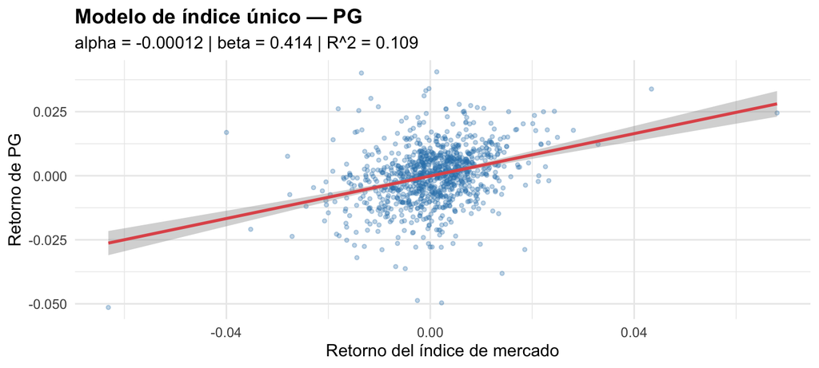

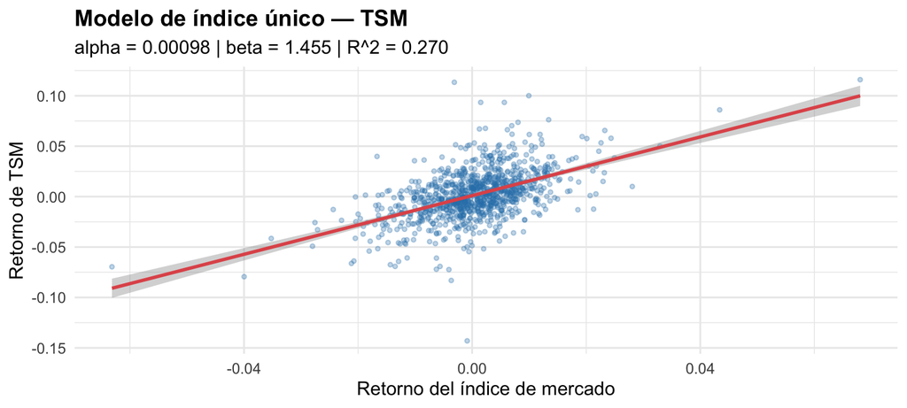

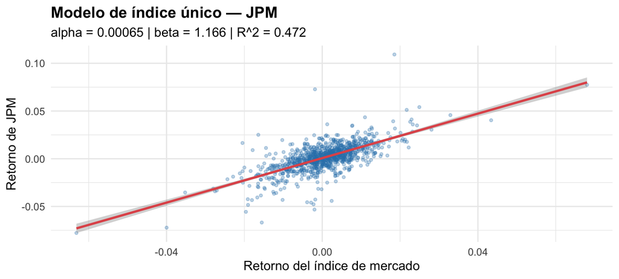

```r
for (a in ACCIONES) print(g_regresion(regs[[a]]))
```

**a) Interpretación de $\alpha$ y $\beta$.** El **intercepto $\alpha$** mide el rendimiento anormal diario: el exceso (o defecto) de rentabilidad que no explica el mercado. En las tres acciones el $\alpha$ es económicamente diminuto y, como se ve por su estadístico $t$, no significativamente distinto de cero, por lo que no hay evidencia de rendimiento anormal sistemático. La **pendiente $\beta$** es la sensibilidad al mercado: cuánto se mueve, en promedio, el retorno de la acción ante un movimiento del índice. Los valores estimados son PG = 0.41, TSM = 1.45, JPM = 1.17.

**b) Significado financiero de la beta.** La beta es la medida del **riesgo sistemático** (no diversificable) de un activo: indica cuánto amplifica ($\beta>1$) o amortigua ($\beta<1$) los movimientos del mercado. Es el insumo central para el costo de capital (CAPM, pregunta 10) y para decidir la exposición de una cartera al ciclo de mercado; una beta alta promete más retorno cuando el mercado sube, pero también mayores pérdidas cuando cae.

# 3 2) ¿Mismo riesgo sistemático que el mercado?

**Ver código**

```r
test1 <- lapply(regs, test_beta, valor = 1)
tab2 <- do.call(rbind, lapply(test1, function(t) data.frame(
  Activo = t$nombre, Beta = t$beta, t_stat = t$t_stat, tc = t$tc,
  IC_inf = t$ic_inf, IC_sup = t$ic_sup, Rechaza_beta_1 = t$rechaza,
  stringsAsFactors = FALSE)))
tabla(tab2, digits = 4,
  caption = "Prueba H0: beta = 1 (mismo riesgo sistemático que el mercado)")
```

Prueba H0: beta = 1 (mismo riesgo sistemático que el mercado)

|  | Activo | Beta | t_stat | tc | IC_inf | IC_sup | Rechaza_beta_1 |
| --- | --- | --- | --- | --- | --- | --- | --- |
| PG | PG | 0.4144 | -15.6396 | 1.9623 | 0.3409 | 0.4879 | TRUE |
| TSM | TSM | 1.4545 | 6.0159 | 1.9623 | 1.3063 | 1.6028 | TRUE |
| JPM | JPM | 1.1662 | 4.2624 | 1.9623 | 1.0897 | 1.2427 | TRUE |

**a)** Se contrasta $H_0:\beta=1$ para cada acción mediante el estadístico $t=(\hat\beta-1)/s_{\hat\beta}$ y el intervalo de confianza al 95%. Cuando el intervalo **contiene el 1**, no se puede rechazar que la acción tenga el mismo riesgo sistemático que el mercado; cuando **no lo contiene**, su riesgo sistemático difiere significativamente del promedio de mercado (la columna *Rechaza_beta_1* lo resume).

**b)** Un incremento del **1% en el retorno del mercado** genera, en promedio, un incremento de **$\beta$%** en el retorno esperado de la acción. Por tanto, con $\beta>1$ el efecto es **superior** (amplifica), con $\beta<1$ es **inferior** (amortigua) y con $\beta=1$ es **proporcional**. Según las betas estimadas, PG (0.41) → inferior/amortigua; TSM (1.45) → superior/amplifica; JPM (1.17) → superior/amplifica.

# 4 3) Riesgo sistemático vs. riesgo específico

**Ver código**

```r
tab3 <- do.call(rbind, lapply(regs, descomposicion_riesgo))
tabla(tab3, digits = 4,
  caption = "Descomposición del riesgo: sistemático (R²) y específico (1−R²)")
```

Descomposición del riesgo: sistemático (R²) y específico (1−R²)

|  | Activo | Var_Total | Var_Sistematica | Var_Especifica | Prop_Sistematica | Prop_Especifica |
| --- | --- | --- | --- | --- | --- | --- |
| PG | PG | 0.0001 | 0.0000 | 0.0001 | 0.1091 | 0.8909 |
| TSM | TSM | 0.0006 | 0.0002 | 0.0004 | 0.2704 | 0.7296 |
| JPM | JPM | 0.0002 | 0.0001 | 0.0001 | 0.4721 | 0.5279 |

**a) y b)** La varianza total de cada acción se descompone como $\mathrm{Var}(R_i)=\beta_i^{2}\mathrm{Var}(R_M)+\mathrm{Var}(\varepsilon_i)$. La **proporción sistemática coincide con el $R^{2}$** de la regresión —la parte del riesgo explicada por el mercado— y la **específica es $1-R^{2}$** —la parte propia de la empresa, diversificable—.

**c)** Comparando las tres, la que tiene mayor $R^{2}$ es la más “arrastrada” por el mercado (menos riesgo diversificable), mientras que la de menor $R^{2}$ conserva una proporción mayor de riesgo específico. Para un inversionista diversificado, solo el componente sistemático ($R^{2}$) sobrevive en una cartera amplia; el específico se cancela al combinar activos.

# 5 4) Correlación de cada acción con el índice

**Ver código**

```r
corr <- sapply(ACCIONES, function(a) cor(as.numeric(ret[, a]), Rm))
tab4 <- data.frame(Activo = ACCIONES, Correlacion = as.numeric(corr),
                   R2 = sapply(regs, function(r) r$R2), stringsAsFactors = FALSE)
tabla(tab4, digits = 4, caption = "Correlación acción–índice y R²")
```

Correlación acción–índice y R²

|  | Activo | Correlacion | R2 |
| --- | --- | --- | --- |
| PG | PG | 0.3303 | 0.1091 |
| TSM | TSM | 0.5200 | 0.2704 |
| JPM | JPM | 0.6871 | 0.4721 |

**a) y b)** El coeficiente de correlación mide la **fuerza de la relación lineal** entre cada acción y el mercado; su cuadrado es exactamente el $R^{2}$ de la regresión. Bajo el criterio visto en clase, $|r|<0.3$ indica relación lineal débil, $0.3\le|r|<0.6$ moderada y $|r|\ge0.6$ fuerte. Comparando las tres acciones, la de mayor correlación es la que más “acompaña” al índice (mayor riesgo sistemático) y la de menor correlación la más independiente del mercado.

# 6 5) Limitaciones de la regresión aplicada a los retornos (Lectura 7 del CFA)

Según la **Sección 3.8 de la Lectura 7**, el análisis de regresión tiene limitaciones importantes al estudiar los retornos de los activos:

- **Inestabilidad de parámetros.** Las relaciones de regresión cambian con el tiempo —igual que las correlaciones— porque cambian los contextos económico, fiscal, regulatorio y político. La beta estimada suele diferir de forma notable según el periodo muestral elegido; una beta de hoy puede no describir el riesgo de mañana.
- **Muestreo de más de una población.** El problema más común es mezclar en una misma muestra periodos o regímenes distintos (p. ej. mercados alcistas y bajistas), lo que distorsiona los coeficientes.
- **Violación de los supuestos.** Si se violan los supuestos del modelo (linealidad, homocedasticidad, independencia de los errores, normalidad), las pruebas de hipótesis y los pronósticos dejan de ser válidos. En series financieras son habituales la **heterocedasticidad** (volatilidad no constante) y la **autocorrelación** (dependencia temporal), que sesgan los errores estándar y, con ellos, la inferencia sobre $\alpha$ y $\beta$.

# 7 6) Limitaciones en el estudio de los mercados financieros y su efecto

La Lectura 7 añade una limitación propia de los mercados: **el conocimiento público de una relación de regresión puede anular su utilidad futura**. Si un analista descubre que cierta característica predice retornos altos y otros la explotan, los precios se ajustan y la relación deja de sostenerse. Sobre el Modelo de Índice Único, estas limitaciones se traducen en:

- **Sobre la beta.** La inestabilidad de parámetros hace que la beta sea sensible al periodo y a la frecuencia de los datos; una beta estimada con ruido conduce a un costo de capital y a una gestión de exposición imprecisos.
- **Sobre el $R^{2}$.** Depende del régimen de mercado (sube en crisis, cuando las correlaciones aumentan); un $R^{2}$ alto en una ventana no garantiza el mismo poder explicativo en otra.
- **Sobre los pronósticos.** Si los supuestos se violan o la relación cambia, los intervalos de confianza y las predicciones del modelo (pregunta 9) pierden validez, y extrapolar fuera del rango observado es especialmente arriesgado.

# 8 7) Comparación de las betas

**Ver código**

```r
orden <- order(betas, decreasing = TRUE)
tab7 <- data.frame(Posicion = seq_along(betas),
                   Activo = ACCIONES[orden], Beta = as.numeric(betas[orden]),
                   stringsAsFactors = FALSE)
tabla(tab7, digits = 4,
  caption = "Betas ordenadas de mayor a menor riesgo sistemático")
```

Betas ordenadas de mayor a menor riesgo sistemático

| Posicion | Activo | Beta |
| --- | --- | --- |
| 1 | TSM | 1.4545 |
| 2 | JPM | 1.1662 |
| 3 | PG | 0.4144 |

**Ver código**

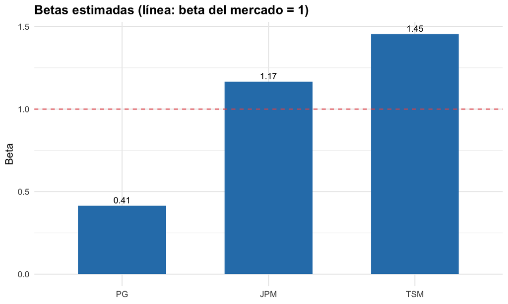

```r
print(g_betas(as.numeric(betas), ACCIONES))
```

**a)** La acción con **mayor sensibilidad** a las variaciones del mercado es **TSM** (beta más alta). **b)** El orden de mayor a menor riesgo sistemático es: TSM > JPM > PG. **c)** La acción con mayor beta **no es necesariamente la mejor inversión**: una beta alta implica más riesgo sistemático y, en un mercado bajista, mayores pérdidas. La decisión debe evaluar el retorno **ajustado por riesgo** (no solo el retorno esperado), el $\alpha$ (habilidad de generar retorno anormal) y el papel del activo dentro de la cartera, no la beta de forma aislada.

# 9 8) Beta y riesgo del portafolio

**Ver código**

```r
beta_p <- beta_portafolio(betas, PESOS_PORT)
Rp     <- as.numeric(zoo::coredata(ret[, ACCIONES]) %*% PESOS_PORT)
reg_p  <- regresion_indice_unico(Rp, Rm, "Portafolio")

tab8 <- data.frame(
  Activo = c(ACCIONES, "Portafolio"),
  Peso   = c(PESOS_PORT, NA),
  Beta   = c(as.numeric(betas), beta_p),
  Prop_Sistematica = c(sapply(regs, function(r) r$R2), reg_p$R2),
  Prop_Especifica  = c(sapply(regs, function(r) 1 - r$R2), 1 - reg_p$R2),
  stringsAsFactors = FALSE)
tabla(tab8, digits = 4,
  caption = "Beta y descomposición de riesgo: activos individuales vs. portafolio")
```

Beta y descomposición de riesgo: activos individuales vs. portafolio

|  | Activo | Peso | Beta | Prop_Sistematica | Prop_Especifica |
| --- | --- | --- | --- | --- | --- |
| PG | PG | 0.3333 | 0.4144 | 0.1091 | 0.8909 |
| TSM | TSM | 0.3333 | 1.4545 | 0.2704 | 0.7296 |
| JPM | JPM | 0.3333 | 1.1662 | 0.4721 | 0.5279 |
|  | Portafolio | NA | 1.0117 | 0.6191 | 0.3809 |

**a) y b)** La **beta del portafolio** es la suma ponderada de las betas, $\beta_p=\sum_i w_i\beta_i =$ 1.012 (idéntica a la beta que se obtiene regresando el retorno del portafolio contra el mercado, lo que valida el cálculo). Se interpreta como la sensibilidad de la cartera al mercado: un movimiento del 1% del índice mueve, en promedio, 1.01% al portafolio. **c) y d)** El portafolio conserva una proporción sistemática ($R^{2}=$ 0.619) **mayor** que la de los activos individuales, porque la diversificación **cancela buena parte del riesgo específico** pero **no** el sistemático: al combinar acciones, el componente propio de cada empresa se compensa y queda, sobre todo, la exposición común al mercado.

# 10 9) Pronóstico por escenarios con intervalo de confianza

**Ver código**

```r
mu_m <- mean(Rm); sd_m <- sd(Rm)
escenarios <- c(Pesimista = mu_m - sd_m, Base = mu_m, Optimista = mu_m + sd_m)

filas <- list()
for (a in ACCIONES) for (e in names(escenarios))
  filas[[length(filas) + 1]] <- pronostico_escenario(regs[[a]], escenarios[[e]], e)
for (e in names(escenarios))
  filas[[length(filas) + 1]] <- pronostico_escenario(reg_p, escenarios[[e]], e)

tab9 <- do.call(rbind, filas)
tab9$Anual_Punto <- anualizar_ef(tab9$Pronostico, DIAS)
tabla(tab9, digits = 5,
  caption = "Pronóstico por escenario con IC 95% (retornos diarios) y punto anualizado")
```

Pronóstico por escenario con IC 95% (retornos diarios) y punto anualizado

| Activo | Escenario | Rm | Pronostico | IC_inf | IC_sup | Anual_Punto |
| --- | --- | --- | --- | --- | --- | --- |
| PG | Pesimista | -0.00832 | -0.00357 | -0.00448 | -0.00266 | -0.59333 |
| PG | Base | 0.00045 | 0.00006 | -0.00058 | 0.00071 | 0.01596 |
| PG | Optimista | 0.00922 | 0.00370 | 0.00279 | 0.00461 | 1.53812 |
| TSM | Pesimista | -0.00832 | -0.01112 | -0.01296 | -0.00928 | -0.93930 |
| TSM | Base | 0.00045 | 0.00164 | 0.00034 | 0.00293 | 0.50987 |
| TSM | Optimista | 0.00922 | 0.01439 | 0.01255 | 0.01623 | 36.55767 |
| JPM | Pesimista | -0.00832 | -0.00905 | -0.01000 | -0.00810 | -0.89780 |
| JPM | Base | 0.00045 | 0.00117 | 0.00050 | 0.00185 | 0.34443 |
| JPM | Optimista | 0.00922 | 0.01140 | 0.01045 | 0.01235 | 16.68568 |
| Portafolio | Pesimista | -0.00832 | -0.00791 | -0.00852 | -0.00730 | -0.86387 |
| Portafolio | Base | 0.00045 | 0.00096 | 0.00053 | 0.00139 | 0.27287 |
| Portafolio | Optimista | 0.00922 | 0.00983 | 0.00922 | 0.01044 | 10.90175 |

**a), b) y c)** Los escenarios se definen sobre el retorno esperado del índice: la **base** es su media histórica diaria (0.045%), y los escenarios **pesimista** y **optimista** la desplazan en $\mp 1$ desviación estándar. Para cada acción y para el portafolio se pronostica $E(R_i)=\hat\alpha_i+\hat\beta_i\,E(R_M)$, con su **intervalo de confianza al 95%** (columnas *IC_inf*/*IC_sup*). La última columna anualiza el pronóstico puntual para facilitar la lectura. **d)** Al pasar de pesimista a optimista, el retorno esperado **crece más rápido en las acciones de beta alta** (mayor pendiente), que también son las que más caen en el escenario adverso: el mayor rendimiento potencial viene acompañado de mayor riesgo, coherente con la interpretación de la beta.

# 11 10) Costo de capital propio (CAPM)

**Ver código**

```r
E_Rm_anual <- anualizar_ef(mu_m, DIAS)
ke   <- sapply(as.numeric(betas), function(b) costo_capital_capm(RF_ANUAL, b, E_Rm_anual))
ke_p <- costo_capital_capm(RF_ANUAL, beta_p, E_Rm_anual)

tab10 <- data.frame(Activo = c(ACCIONES, "Portafolio"),
                    Beta = c(as.numeric(betas), beta_p),
                    Ke_anual = c(ke, ke_p), stringsAsFactors = FALSE)
tabla(tab10, digits = 4,
  caption = paste0("Costo de capital propio (CAPM). Rf = ", pct(RF_ANUAL,2),
                   " EA, E(Rm) = ", pct(E_Rm_anual,2), " EA"))
```

Costo de capital propio (CAPM). Rf = 4.69% EA, E(Rm) = 12.03% EA

| Activo | Beta | Ke_anual |
| --- | --- | --- |
| PG | 0.4144 | 0.0773 |
| TSM | 1.4545 | 0.1537 |
| JPM | 1.1662 | 0.1325 |
| Portafolio | 1.0117 | 0.1212 |

**a), b) y c)** El costo de capital propio se calcula con $K_e=R_f+\beta\big(E(R_M)-R_f\big)$, usando $R_f=$ 4.69% EA y la rentabilidad esperada del índice $E(R_M)=$ 12.03% EA (media histórica anualizada). La relación es directa: **a mayor beta, mayor $K_e$**, porque el mercado exige más rentabilidad a los activos con más riesgo sistemático. El $K_e$ del portafolio queda entre los de sus componentes, acorde con su beta ponderada. **d)** La alternativa más atractiva no es simplemente la de mayor retorno esperado, sino la que ofrece el mejor balance entre **beta, riesgo sistemático, retorno esperado y costo de capital**: una acción con beta y $K_e$ altos solo conviene si su retorno esperado supera con holgura ese costo exigido.

# 12 11) Gradiente y matriz Hessiana en la estimación por MCO

**Función objetivo.** Estimar la regresión $R_i=b_0+b_1 R_M+\varepsilon$ por mínimos cuadrados equivale a minimizar la suma de errores al cuadrado:

$$S(b_0,b_1)=\sum_{t=1}^{n}\big(y_t-b_0-b_1 x_t\big)^2,$$

donde $y_t=R_{i,t}$ y $x_t=R_{M,t}$.

**Gradiente.** Las derivadas parciales respecto a los parámetros son:

$$\frac{\partial S}{\partial b_0}=-2\sum_t\big(y_t-b_0-b_1 x_t\big),\qquad
\frac{\partial S}{\partial b_1}=-2\sum_t x_t\big(y_t-b_0-b_1 x_t\big).$$

Igualar el gradiente a cero (condición de primer orden) da las **ecuaciones normales**, cuya solución son los estimadores MCO:

$$\hat b_1=\frac{\sum_t (x_t-\bar x)(y_t-\bar y)}{\sum_t (x_t-\bar x)^2},\qquad
\hat b_0=\bar y-\hat b_1\bar x.$$

**Matriz Hessiana.** Las segundas derivadas forman la Hessiana:

$$H=\begin{pmatrix}\dfrac{\partial^2 S}{\partial b_0^2} & \dfrac{\partial^2 S}{\partial b_0\partial b_1}\\[2mm]
\dfrac{\partial^2 S}{\partial b_1\partial b_0} & \dfrac{\partial^2 S}{\partial b_1^2}\end{pmatrix}
=2\begin{pmatrix} n & \sum_t x_t\\ \sum_t x_t & \sum_t x_t^2\end{pmatrix}=2\,X^{\top}X.$$

**Interpretación y condición de segundo orden.** La Hessiana es **constante** (no depende de $b$) y **definida positiva**: su determinante es $4\big(n\sum x_t^2-(\sum x_t)^2\big)=4n\sum_t(x_t-\bar x)^2>0$ siempre que $x$ no sea constante. Por tanto $S$ es una función **convexa** y el punto crítico hallado con el gradiente es un **mínimo global** (no un máximo ni un punto silla). Así, gradiente (CPO) y Hessiana (CSO) garantizan que los estimadores MCO minimizan efectivamente el error.

**Ver código**

```r
gh <- ols_gradiente_hessiana(Rm, regs[[1]]$datos$Ri)
cat("Verificación numérica (acción", ACCIONES[1], "):\n")
```

```
Verificación numérica (acción PG ):
```

**Ver código**

```r
cat("  Gradiente en el óptimo (≈ 0):", paste(signif(gh$gradiente, 3), collapse = ", "), "\n")
```

```
  Gradiente en el óptimo (≈ 0): 0.00000000000000059, 0.000000000000000135
```

**Ver código**

```r
cat("  Valores propios de la Hessiana:", paste(signif(gh$valores_propios, 4), collapse = ", "), "\n")
```

```
  Valores propios de la Hessiana: 2004, 0.1539
```

**Ver código**

```r
cat("  Hessiana definida positiva:", gh$definida_positiva, "\n")
```

```
  Hessiana definida positiva: TRUE
```

**Verificación.** El gradiente evaluado en los estimadores MCO es prácticamente **cero** y los valores propios de la Hessiana son **positivos**, confirmando numéricamente que la solución es el mínimo global de $S$.

*Nota.* Todos los cálculos usan retornos logarítmicos diarios de los últimos 4 años del índice ^NYA y de las acciones seleccionadas. La tasa libre de riesgo (4.69% EA) y los pesos del portafolio son supuestos editables en el bloque de configuración. El código se encuentra en `funciones_indice_unico.R` y en este documento.